# R Markdown: Syntax & Code Chunks

## R Markdown Basics

**R Markdown Basics**

R Markdown file contains three important types of content:

1. (Optional) YAML header surrounded by `---`s
2. Chunks of R code surrounded by ```
3. Text mixed with simple text formatting like # heading and *italics*

## Where do we go from here?

- Figure out markdown syntax
- Look at "Notebook" feature
- Check options for code chunks
- Change type of output

## R Markdown Syntax Can Include…

- Plain text
- End a line with two spaces to start a new paragraph
  - Line breaks are not always added when you return!
  - Two spaces and a return drop marked up text down.
  - Can specify `<br>` as a line break
- `*italics*` *and* `_italics_`
- `**bold**` **and** `__bold__`
- `superscript^2^` becomes superscript<sup>2</sup>
- `~~strikethrough~~` becomes strikethrough
- Modify text in your .Rmd file and click Knit -> Knit to HTML (at the top)

## R Markdown Syntax

- `[link](https://www.rstudio.com/wp-content/uploads/2015/03/rmarkdown-reference.pdf)` becomes [link](https://www.rstudio.com/wp-content/uploads/2015/03/rmarkdown-reference.pdf)
- `# Header 1` becomes a large font header
- `## Header 2` becomes a slightly smaller font header
- Goes to 6 headers
- Use of headers can automatically create a Table of Contents!
- Include an image: `![](path/to/file.png)`
- `code` becomes `code`
- Modify text in your .Rmd file and click Knit -> Knit to HTML (at the top)

## R Markdown Syntax

- Can do lists: be sure to end each line with two spaces!
- Indent sub lists four spaces

```
* unordered list
* item 2
  + sub-item 1
  + sub-item 2

1. ordered list
2. item 2
  + sub-item 1
  + sub-item 2
```

- unordered list
- item 2
  - sub-item 1
  - sub-item 2
1. ordered list
2. item 2
   - sub-item 1
   - sub-item 2

## R Markdown Syntax

- Can include nice tables (renders differently in slides than html doc)

```
Table Header  | Second Header | Col 3
------------- | ------------- | -----------
Table Cell    | Cell (1, 2)   | Cell (1, 3)
Cell (2, 1)   | Cell (2, 2)   | Cell (2, 3)
```

| Table Header | Second Header | Col 3 |
| --- | --- | --- |
| Table Cell | Cell (1, 2) | Cell (1, 3) |
| Cell (2, 1) | Cell (2, 2) | Cell (2, 3) |

- Add a list and a table in your .Rmd file and click Knit -> Knit to HTML (at the top)

## Code Chunks

We've already seen how to include an R code chunk:

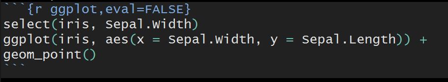

- Add chunk via typing  
  ```{r}  
  code  
  ```
- or `Ctrl/Cmd + Alt + I`
- Any R code can go into the chunk
- Code can be added in line: Ex: Iris has 150 observations
- Added by beginning with back-tick `r` and ending with a back-tick: Iris has `r `length(iris$Sepal.Length)``

## More About Notebook Functionality

Data science notebook - virtual notebook environment used for literate programming

- Pairs the functionality of word processing software with a programming language
- Rendered markdown document captures R code and process
- Blurs line between interactive exploration and long-term code capture.

## Notebook Functionality

Within a chunk:

- Execute code with `Cmd/Ctrl + Shift + Enter` or with "Run"

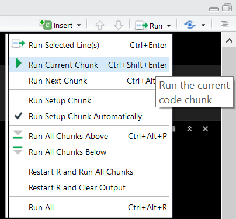

- Results show up in editor!

## Notebook Functionality

- Allows for quick iteration within a chunk: editing and re-executing - when you are happy, you move on and start a new chunk.
- Can run all code chunks with `Ctrl/Cmd + Alt + R`
- Can develop code and record your thoughts - similar to classic lab notebook in the physical sciences
- Go back to markdown template document, execute code chunk in-line and all code chunks. Add an inline code piece.

## Back to Code Chunks

- Many options depending on chunk purpose!
- Can hide/show code with `echo = FALSE/TRUE`
- Can choose if code is evaluated with `eval = TRUE/FALSE`
- `Include = FALSE` is equivalent to `echo = FALSE, eval = TRUE`
- `message = TRUE/FALSE` and `warning = TRUE/FALSE` can turn on/off displaying messages/warnings
- `error = TRUE` allows file to be created with code that has an error

## Back to Code Chunks

- Options useful for set-up code (usually first chunk after YAML header)
- Can set global options for all chunks
- Allows for easy change of audience!

## Back to Code Chunks

- Options useful for set-up code (usually first chunk after YAML header)
- Can set global options for all chunks
- Allows for easy change of audience!

For a higher up

```
opts_chunk$set(echo = FALSE, eval = TRUE, warning = FALSE)
```

For a collaborator

```
opts_chunk$set(echo = TRUE, eval = TRUE, warning = FALSE)
```

## Code Chunks

Can name code chunks to help organization!

- When calling a chunk, add name after `r`

```{r name-of-chunk, options…}  
code  
```

## Code Chunks

Can name code chunks to help organization!

- When calling a chunk, add name after `r`

```{r name-of-chunk, options…}  
code  
```

- TOC type menu in bottom left of notebook editor!

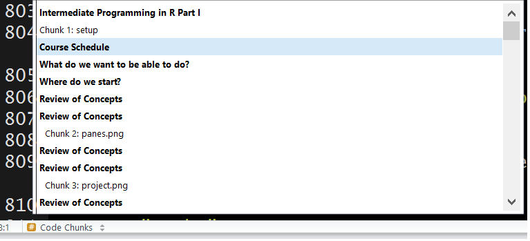

## Code Chunks

In a large analysis it may take a long time to run code chunks/knit your document

- Can "Cache" results! Code will only rerun if it has changed.
- Option to set up code dependencies using chunk names
- Use `cache = TRUE` in code chunk definition
- Delete folders created to rerun everything
- Modify *global options* in `setup` R chunk after your YAML header. Make changes and see differences! (Local settings overwrite global.) (Add `library(tidyverse)` to a code chunk to have messages that would pop up!)

## Images/Equations and Misc.

Adding images in markdown: `![](path/to/file)`

- Not ideal… difficult to control size/scale
- Better way to add images use R code!
- `knitr` package has `include_graphics` function
- Use knitr or code chunk options to control size/scale!
- Ex:  
  ```{r graphics, out.width = "800px", echo = FALSE} knitr::include_graphics("path/to/file")  
  ```

## Images/Equations and Misc.

Adding Equations

- Inline equation: `$A = \pi*r^{2}$` becomes \(A = \pi*r^{2}\)
- Block equation `$$A = \pi*r^{2}$$` becomes \[A = \pi*r^{2}\]
- Outputting equations for HTML is done through MathJax (javascript)
- For PDFs it is done through LaTeX (may need to install)

## Images/Equations and Misc.

Outputting data tables better with `kable` from `knitr` package

```r
summary(cars)
```

```
##      speed           dist
##  Min.   : 4.0   Min.   :  2.00
##  1st Qu.:12.0   1st Qu.: 26.00
##  Median :15.0   Median : 36.00
##  Mean   :15.4   Mean   : 42.98
##  3rd Qu.:19.0   3rd Qu.: 56.00
##  Max.   :25.0   Max.   :120.00
```

```r
kable(summary(cars))
```

[output not shown]